# Kryptos K3

Kenny Shirley

September 1, 2019

## Solving Kryptos 3 (“K3”)

K3 is known to have been encoded using a transposition cipher, which means that the letters in the ciphertext are the same exact letters of the plaintext, but they are scrambled.

There are lots of different types of [transposition ciphers](https://en.wikipedia.org/wiki/Transposition_cipher): (rail fence, route, etc.). Here we’ll show how to decode a single or double columnar transposition cipher.

## Example: Single Columnar Transposition

First, let’s walk through a single columnar transposition cipher.

Suppose our message is the sequence of integers from 1 to, say, 37. (We’ll use numbers in order since it makes it easier to see the pattern to decode).

Since the main technique for encoding a message using a columnar transposition cipher is writing the message in a two-dimensional grid, we first need to pad the length of the message to a non-prime number, if the original message length is prime.

Let’s pad our length-37 message to length 40, by appending three “junk” characters at the end of the message. In this example, it will just be the numbers 38, 39, and 40.

Next, we must write the message in a two-dimensional grid. Let’s refer to this grid as a matrix, with rows and columns. We must choose how many rows it will have. Our possible choices, for a length-40 message, are 2, 4, 5, 8, 10, and 20.

Let’s choose 4 rows.

The message is written like this:

```
    1    2    3    4    5    6    7    8    9    10
   11   12   13   14   15   16   17   18   19    20
   21   22   23   24   25   26   27   28   29    30
   31   32   33   34   35   36   37   38   39    40
```

Next, we “rotate” it 90 degrees clockwise, and read the resulting message from left-to-right, top-to-bottom:

```
 31 21 11  1 32 22 12  2 33 23 13  3 34 24 14  4 ... 39 29 19  9 40 30 20 10
```

This is the encoded message, or ciphertext.

To decrypt it, we only need to know the total number of characters in the message, and we must guess the dimension of the matrix used to encode it, i.e. the number of rows.

Given the number of rows, $r$, and the total length of the message, $n$, where $n$ is not prime, and $n$ is evenly divisible by $r$, the formula for the $j^\text{th}$ plaintext character of a single columnar transposition cipher is given by:

$$(r \times j - 1) \bmod (n + 1) + 1,$$
for $j = 1, 2, ..., n$.

In our example, the plaintext is given by the following indices of the cipher text: 4, 8, 12, 16, 20, 24, 28, 32, 36, 40, 3, 7, 11, …, 33, 37.

The code below decrypts the ciphertext:

```r
# encode the 'message'
cipher_text <- as.vector(t(t(matrix(1:40, 4, 10, byrow = TRUE))[, 4:1]))

# set the number of rows and the length of the message
r <- 4
n <- length(cipher_text)

# the solution:
index <- (seq(r, by = r, length = n) - 1) %% (n + 1) + 1
index
```

```
 [1]  4  8 12 16 20 24 28 32 36 40  3  7 11 15 19 23 27 31 35 39  2  6 10 14 18
[26] 22 26 30 34 38  1  5  9 13 17 21 25 29 33 37
```

```r
cipher_text[index]
```

```
 [1]  1  2  3  4  5  6  7  8  9 10 11 12 13 14 15 16 17 18 19 20 21 22 23 24 25
[26] 26 27 28 29 30 31 32 33 34 35 36 37 38 39 40
```

Let’s try this on a real English language message (just an example that we made up). Suppose we have the following ciphertext, and we assume that it has been encoded using a single columnar transposition.

```
[1] "EPFLAMSYHTRALYOINEOETEONNALDPHDUTIMLIAEMKOGEOERRYIYOIM"
```

Let’s decode it.

```r
n <- length(cipher_text)
r_vec <- which(floor(n / (2:(n/2))) == n / (2:(n/2))) + 1
```

First, note that it is 54 characters long. The divisors of 54 are 2, 3, 6, 9, 18, and 27. These are the possible choices of how many rows are in the matrix that defined the single columnar transposition.

We’ll decode the cipher text using each possible value, and we’ll score the potential solutions using a bigram model for English, as described in the solution to K1.

Here are the log-likelihoods of the six possible solutions, and the plaintext solutions:

```r
candidate <- vector("list", length(r_vec))
loglik <- numeric(length(r_vec))
for (i in 1:length(r_vec)) {
  index <- (seq(r_vec[i], by = r_vec[i], length = n) - 1) %% (n + 1) + 1
  candidate[[i]] <- cipher_text[index]
  loglik[i] <- markov_score(sequence = candidate[[i]])
}
data.frame(loglik = loglik, message = sapply(candidate, paste, collapse = "")) %>%
  arrange(desc(loglik))
```

```
     loglik                                                message
1 -139.4713 HELLOMYNAMEISINIGOMONTOYAYOUKILLEDMYFATHERPREPARETODIE
2 -171.4899 PLMYTAYIEEENADHUILAMOEERIOMEFASHRLONOTONLPDTMIEKGORYYI
3 -176.6875 LMAINONYOIEYTREROEEONEIGOOYKLMAERATIHLYMSIMTAULDFHPPED
4 -178.0476 MAENHLORMARNOPMKRILTIEDIMEOFHOTLTEOYPYYEAUAEIESLONDIGY
5 -184.0255 FMHAOETNLHTLEOORYMPAYRYNEOAPUMAKERIIELSTLIOENDDIIMGEYO
6 -205.1140 ELMNMIIIOOTYYUILDYAHRRPRTDEHLOYAESNGMNOAOKLEMFTEPEAEOI
```

The most likely solution is $e^{32}$ times more likely than the second most likely solution, and it’s recognizable as the classic line from The Princess Bride:

```
"Hello. My name is Inigo Montoya. You killed my father. Prepare to die."
```

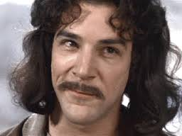

We correctly identified our solution!

## Was K3 encoded using a single columnar transposition?

Let’s test whether K3 was encoded using a single columnar transposition.

Here are the 337 characters of K3 in order:

```r
cipher_text <- readLines("ciphertext.txt")
kryptos3a <- unlist(strsplit(cipher_text[15:24], ""))
kryptos3b <- unlist(strsplit(cipher_text[25], ""))[1:27]
K3 <- c(kryptos3a, kryptos3b)
K3
```

```
  [1] "E" "N" "D" "Y" "A" "H" "R" "O" "H" "N" "L" "S" "R" "H" "E" "O" "C" "P"
 [19] "T" "E" "O" "I" "B" "I" "D" "Y" "S" "H" "N" "A" "I" "A" "C" "H" "T" "N"
 [37] "R" "E" "Y" "U" "L" "D" "S" "L" "L" "S" "L" "L" "N" "O" "H" "S" "N" "O"
 [55] "S" "M" "R" "W" "X" "M" "N" "E" "T" "P" "R" "N" "G" "A" "T" "I" "H" "N"
 [73] "R" "A" "R" "P" "E" "S" "L" "N" "N" "E" "L" "E" "B" "L" "P" "I" "I" "A"
 [91] "C" "A" "E" "W" "M" "T" "W" "N" "D" "I" "T" "E" "E" "N" "R" "A" "H" "C"
[109] "T" "E" "N" "E" "U" "D" "R" "E" "T" "N" "H" "A" "E" "O" "E" "T" "F" "O"
[127] "L" "S" "E" "D" "T" "I" "W" "E" "N" "H" "A" "E" "I" "O" "Y" "T" "E" "Y"
[145] "Q" "H" "E" "E" "N" "C" "T" "A" "Y" "C" "R" "E" "I" "F" "T" "B" "R" "S"
[163] "P" "A" "M" "H" "H" "E" "W" "E" "N" "A" "T" "A" "M" "A" "T" "E" "G" "Y"
[181] "E" "E" "R" "L" "B" "T" "E" "E" "F" "O" "A" "S" "F" "I" "O" "T" "U" "E"
[199] "T" "U" "A" "E" "O" "T" "O" "A" "R" "M" "A" "E" "E" "R" "T" "N" "R" "T"
[217] "I" "B" "S" "E" "D" "D" "N" "I" "A" "A" "H" "T" "T" "M" "S" "T" "E" "W"
[235] "P" "I" "E" "R" "O" "A" "G" "R" "I" "E" "W" "F" "E" "B" "A" "E" "C" "T"
[253] "D" "D" "H" "I" "L" "C" "E" "I" "H" "S" "I" "T" "E" "G" "O" "E" "A" "O"
[271] "S" "D" "D" "R" "Y" "D" "L" "O" "R" "I" "T" "R" "K" "L" "M" "L" "E" "H"
[289] "A" "G" "T" "D" "H" "A" "R" "D" "P" "N" "E" "O" "H" "M" "G" "F" "M" "F"
[307] "E" "U" "H" "E" "E" "C" "D" "M" "R" "I" "P" "F" "E" "I" "M" "E" "H" "N"
[325] "L" "S" "S" "T" "T" "R" "T" "V" "D" "O" "H" "W" "?"
```

The last character is a question mark. We will igonre it for now, treating K3 as if it only has 336 characters.

What are the possible numbers of rows that could have been used to encode K3 using a single columnar transposition? There are 18 possible values: 2, 3, 4, 6, 7, 8, 12, 14, 16, 21, 24, 28, 42, 48, 56, 84, 112, 168.

```r
K3 <- K3[1:336]
n <- length(K3)
r_vec <- which(floor(n / (2:(n/2))) == n / (2:(n/2))) + 1
```

For each of these 18 values, we’ll compute the log-likelihood of the solution, and the first 20 characters of the solution:

```r
candidate <- vector("list", length(r_vec))
loglik <- numeric(length(r_vec))
for (i in 1:length(r_vec)) {
  index <- (seq(r_vec[i], by = r_vec[i], length = n) - 1) %% (n + 1) + 1
  candidate[[i]] <- K3[index]
  loglik[i] <- markov_score(sequence = candidate[[i]])
}
data.frame(loglik = loglik,
           message = sapply(candidate, function(x) paste(x[1:20], collapse = ""))) %>%
  arrange(desc(loglik))
```

```
      loglik              message
1  -1128.587 EETWLHCHEHEONMADNABV
2  -1128.821 EWHHHOMDAVPTSRRTBTTS
3  -1138.616 NYHONSHOPEIIYHAAHNEU
4  -1138.984 HMEEOETITIUWSSLNIHON
5  -1142.262 DHHSEPOISACNYDLLHORM
6  -1142.614 EIWNNHEDOTDDCEVHSTAB
7  -1144.852 RHOHTDNMTIEECNREHOWO
8  -1151.602 DEOEETAWLLFHACHHUETH
9  -1153.993 HSPIANDLOMNNSEATECDA
10 -1158.283 ODTEROEEFESTDARWELEL
11 -1161.210 MEEIIWSNHNRHOEHDOONT
12 -1163.500 OALPNTESYBASMIAIDHFI
13 -1164.519 YOSOEIHANULLSMMPANPN
14 -1165.710 HHDMIENEOOCEETEIRTGI
15 -1173.490 ILNTAYESTATHCWBLHMHE
16 -1174.496 SINLMNETCAIYEEYSTTTA
17 -1179.412 OOIAULMPNNITNEASHYAB
18 -1180.648 LTYSAHWLMEAOEHSWTORL
```

The most likely solution is not much more likely than the next-most likely solution, and from the first 20 characters, it is clearly not an English language sentence or phrase. It looks like K3 was not a single columnar transposition.

## Double Columnar Transposition

A double columnar transposition is done by repeating a single columnar transposition twice. Just take the cipher text from a single columnar transposition, embed it into another two-dimensional grid (choosing a potentially different number of rows for the embedding), and then rotate and read off the text row-wise again to produce the final cipher text.

Decrypting a double columnar transposition is no more difficult than decrypting a single columnar transposition: just use the same formula from the single transposition decryption method, but replace $r$, the number of rows, with $r_1 \times r_2$, the product of the numbers of rows used for each individual transposition.

This also implies that using any pair of values of $r_1$ and $r_2$ for which their product is the same yields the same cipher text. Thus, we only need to test every unique value of $r_1 \times r_2$ to decrypt a double transposition cipher.

Let’s skip right to the results on K3. Now we have $18 \times 18 = 324$ possible values of $(r_1, r_2)$, but only 73 unique values of their product.

```r
# list all combinations of (r1, r2):
grid <- expand.grid(r_vec, r_vec) %>%
  rename(r1 = Var1, r2 = Var2) %>%
  mutate(r = r1 * r2)

# only retain those with a unique product:
grid <- grid[!duplicated(grid$r), ]
m <- nrow(grid)  # m = 73

# loop through them and compute the solution:
candidate <- vector("list", m)
loglik <- numeric(m)
for (i in 1:m) {
  r <- grid$r[i]
  index <- (seq(r, by = r, length = n) - 1) %% (n + 1) + 1
  candidate[[i]] <- K3[index]
  loglik[i] <- markov_score(sequence = candidate[[i]])
}

out <- data.frame(grid,
                  loglik = loglik,
                  first_part = sapply(candidate, function(x) paste(x[1:30], collapse = "")),
                  message = sapply(candidate, paste, collapse = "")) %>%
  arrange(desc(loglik))

select(out, -message) %>% head(10)
```

```
    r1  r2     r     loglik                     first_part
1   48   4   192  -836.5672 SLOWLYDESPARATLYSLOWLYTHEREMAI
2  112   8   896 -1080.8038 DHTNDMACDELMORPEGAAXTHHDFSECTL
3  112  16  1792 -1103.1631 HNMCEMREAXHDSCLSEGLNAVEAILFOIT
4   84   3   252 -1109.0188 THEOAALTFRPTIFRLARIEEAGEWNPISH
5  168  42  7056 -1117.5848 IRRDTEOWELABPSIEPDYDERAENSHLRL
6   42  21   882 -1118.8725 MLEFNECIEWGAOTPRHRWENONRQOIMGA
7   12   3    36 -1121.2989 NNCYYTTHNBXMTHOOYENSENCOASNOCT
8  112 112 12544 -1124.2838 RCAOEUEIEPTAHYDFTNEAHMUROEDSYT
9   21  21   441 -1126.3613 NMCLREOFSNWEYCRILETWSGCAGOETIP
10 168   6  1008 -1127.1190 OTTLEEIDEEFHNRDALKILRSEESEIDEE
```

It worked! The most likely solution is clearly an English sentence, and is much more likely than any other candidate solution.

The full text of the solution is:

[output not shown]

Or, when you break it up into words:

```
SLOWLY DESPARATLY SLOWLY THE REMAINS OF PASSAGE DEBRIS THAT ENCUMBERED
THE LOWER PART OF THE DOORWAY WAS REMOVED
WITH TREMBLING HANDS I MADE A TINY BREACH IN THE UPPER LEFT HAND CORNER
AND THEN WIDENING THE HOLE A LITTLE I INSERTED THE CANDLE AND PEERED IN
THE HOT AIR ESCAPING FROM THE CHAMBER CAUSED THE FLAME TO FLICKER
BUT PRESENTLY DETAILS OF THE ROOM WITHIN EMERGED FROM THE MIST X
CAN YOU SEE ANYTHING Q
```